# Valores extremos aplicado ao fluxo de veículos

A teoria dos valores extremos é um ramo da estatística que estuda a distribuição e a probabilidade de eventos raros ou extremos, como inundações, terremotos, furacões, etc. Essa teoria é útil para modelar e prever o comportamento de fenômenos que fogem da normalidade e que podem ter consequências graves ou catastróficas. Dessa forma, é necessário encontrar os valores mais altos de uma série ou de uma distribuição. Esses números são conhecidos como valores extremos.

Essa teoria pode ser aplicada em muitas áreas. A mais comum é a área climática, para prever chuvas mais fortes ou temperaturas mais altas, entretanto, há exemplos aplicados ao esporte, à área financeira, e à demanda de serviços, entre outras.”

A fórmula é essa:

$$p(x|\xi, \sigma, \mu)\ = \
\left\{ \begin{array}{rcl}
\frac{1}{\sigma}(1 + \xi\frac{x - \mu}{\sigma})^{-\frac{1}{\xi}},\ \mbox{se}& \xi \neq 0\\
\frac{1}{\sigma}\exp\left\{-\frac{(x - \mu)}{\sigma}\right\}, \ \mbox{se}& \xi = 0
\end{array}\right.$$

Bonita, mas acredito que não seja interessante explicá-la detalhadamente, mas o relevante é vermos um exemplo de sua aplicação.

```r
library(tidyverse)
library(POT)
# setwd("D:/OneDrive/DEV/strans_fluxo/files")
```

obs.: Foi preciso criar um arquivo com a frequência, pois para trabalhar com todos arquivos, exigiria muito da máquina que utilizo. O código abaixo consiste no método utilizado para construir o arquivo com dados que foram utilizados.

```r
# csv_files <- list.files(path = "D:/OneDrive/DEV/strans_fluxo/files/", pattern = "T1113")

# combined_df <- NULL

# # 362 files
# for (file in csv_files) {
#   df <- read.csv(file, fileEncoding = "UTF-8")
#   combined_df <- rbind(combined_df, df)
# }

# combined_df$DataHoraPassagem = lubridate::ymd_hms(combined_df$DataHoraPassagem)
# combined_df$day = lubridate::date(combined_df$DataHoraPassagem)
```

```r
# combined_df$day|>
#   table()|>
#   as.data.frame()|>
#   write.csv("fluxo_day.csv")
```

# Aplicação ao fluxo de trânsito

Nas cidades, a quantidade de veículos circulando diariamente influencia o funcionamento da cidade (e o humor das pessoas). Uma grande quantidade de veículos significa mais lentidão e maior risco de acidentes. Uma análise descritiva pode ajudar a entender a frequência de veículos nas ruas, mas em grandes quantidades, a situação pode ser apenas a ponta do iceberg para o caos.

```r
# loading the file
fluxo_day = read.csv("fluxo_day.csv")
```

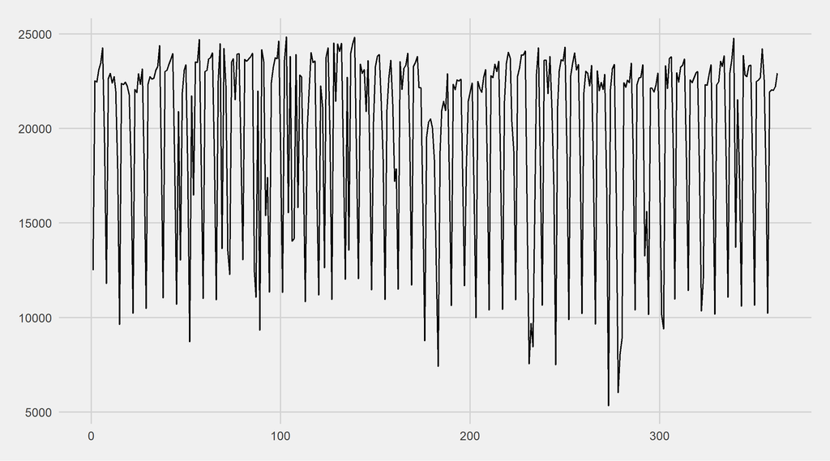

```r
#chat
fluxo_day|>
ggplot2::ggplot()+
ggplot2::aes(x = X, y = Freq)+
ggplot2::geom_line()+
ggthemes::theme_fivethirtyeight()
```

A teoria dos valores extremos pode ser aplicada para determinar em quais dias o fluxo de veículos foi muito intenso e qual valor esperar até determinado período. Para isso, o passo determinante é a escolha do limiar, ou seja, o valor em que a distribuição se torna uma distribuição de extremos. Esse processo é feito através de análises gráficas.

Após esse processo, podemos criar nosso modelo que explica os dados extremos.

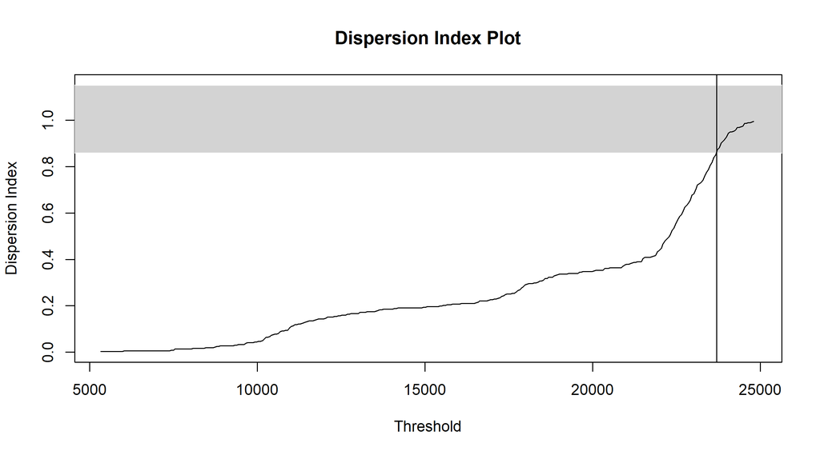

```r
DfGrapif = data.frame(time = c(1:length(fluxo_day$Freq)),
                      obs = fluxo_day$Freq)
diplot(DfGrapif)
abline(v = 23700)
```

O comando a seguir apresentar os valores dos parâmetros da função

```r
ajuste = fitgpd(fluxo_day$Freq, 23700)
ajuste
```

```
Estimator: MLE
 Deviance: 654.9398
      AIC: 658.9398

Varying Threshold: FALSE

  Threshold Call: 23700
    Number Above: 47
Proportion Above: 0.1298

Estimates
   scale     shape
625.9130   -0.4748

Standard Error Type: observed

Standard Errors
   scale     shape
131.5742    0.1675

Asymptotic Variance Covariance
       scale       shape
scale   1.731e+04  -2.080e+01
shape  -2.080e+01   2.807e-02

Optimization Information
  Convergence: successful
  Function Evaluations: 56
  Gradient Evaluations: 23
```

# Análise da qualidade do modelo

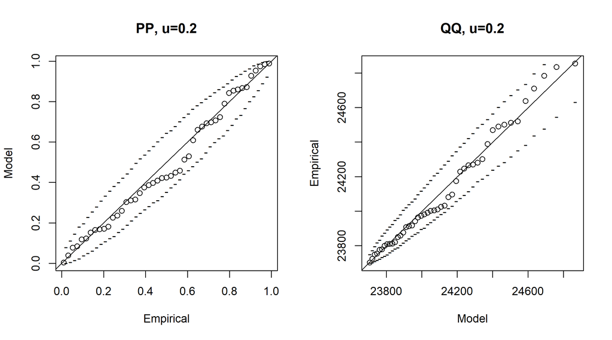

```r
par(mfrow=c(1,2))
pp(ajuste,main="PP, u=0.2");qq(ajuste,main="QQ, u=0.2")
```

# Fluxo esperado

Utilizando a formula $p = 1 - \frac{1}{t}$, podemos verificar o maior fluxo esperado para um período determinado na escala em uso. No caso em análise, dias. O pacote possui funções que apresentam trabalham a formula e escolhemos calcular entre o intervalo de 10 a 60 dias

O gráfico a seguir mostra o o valores esperados de acordo com os dias de intevalo e o intervalo de confiança.

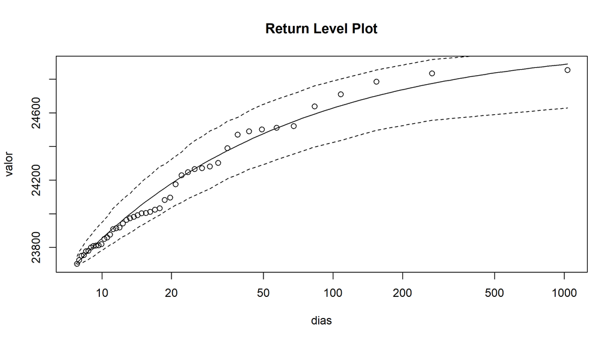

```r
retornos = retlev(ajuste,npy= ajuste$pat, xlab="dias", ylab="valor")
```

A tabela a seguir apresenta os valores esperados de acordo com uma sequencia que foi criada de 10 a 60 dias

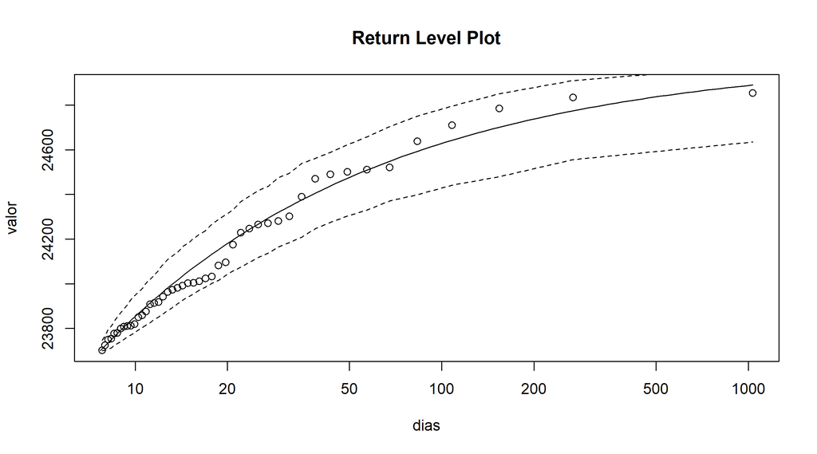

```r
retornos = retlev(ajuste,npy= ajuste$pat, xlab="dias", ylab="valor")
```

```r
#create a sequence
days = seq(10,60,5)
fluxo_etv = c()

for (i in days) {
  result <- retornos(i)
  fluxo_etv <- c(fluxo_etv, as.numeric(result))
}

data.frame(Dias = c(days),
          Fluxo = c(fluxo_etv))|>
          knitr::kable()
```

| Dias | Fluxo |
| --- | --- |
| 10 | 23853.70 |
| 15 | 24057.64 |
| 20 | 24180.29 |
| 25 | 24264.53 |
| 30 | 24327.04 |
| 35 | 24375.83 |
| 40 | 24415.30 |
| 45 | 24448.10 |
| 50 | 24475.92 |
| 55 | 24499.92 |
| 60 | 24520.90 |

Os dados indicam que em 10 dias o maior valor extremo esperado é de 23.854 veículos. Ocorre um crescimento do valores devido pois a distância de tempos ocasiona um aumento do valor e expanção do intervalo de confiança.

É importante destacar que o valor do limiar pode ser determinado de forma abritária. No exemplo, utilizamos o valor calculado, mas poderiamos usar um valor específico. Esta situção depende da pesquisa e da busca dos resutaldo mais adequados a realidade.